# Survey of the data for Final Project, Part B, and an example of EDA

# Introduction

In this document, we survey the data from NLSY ’79 forming the basis for this assignment. We also give an example of exploratory data analysis as a model of what we expect as a solution to this assignment.

Many factors effect a person’s income over a period of years. Of course, someone’s chosen profession is the principle factor. Related to this factor is level of education, since many high-paying professions require a college degree or an additional professional degree. Other factors effecting income may be due to social biases concerning gender or race. In Part B of your final project you are asked to explore the data and formulate hypotheses concerning the effect on income of some combination education and physical characteristics for respondents to NLSY ’79.

# Description of the data

In part A of this project you tidied data on height over a period of years for respondents from NLSY ’79. In part B, we have downloaded and tidied the following datasets containing additional data. Please use the height data supplied here instead of the dataset you prepared in Part A. This ensures that all student teams are working with the same raw materials.

```r
library(tidyverse)
```

## Income

Load and examine the income data as follows.

```r
load("income_data_nlsy79.RData")
```

```r
glimpse(income_data_nlsy79)
```

```
## Observations: 291,778
## Variables: 3
## $ CASEID <int> 1, 2, 3, 4, 5, 6, 7, 8, 9, 10, 11, 12, 13, 14, 15, 16, 17…
## $ income <int> NA, 10000, 7000, 1086, 2300, 3250, 4975, 7500, 5000, 9000…
## $ year   <int> 1982, 1982, 1982, 1982, 1982, 1982, 1982, 1982, 1982, 198…
```

The integer `CASEID` codes the individual respondents. The number of respondents is found as follows.

```r
length(unique(income_data_nlsy79$CASEID))
```

```
## [1] 12686
```

The integer `year` variable refers to the year the data was collected. The years for which we have data are revealed by:

```r
unique(income_data_nlsy79$year)
```

```
##  [1] 1982 1983 1984 1985 1986 1987 1988 1989 1990 1991 1992 1993 1994 1996
## [15] 1998 2000 2002 2004 2006 2008 2010 2012 2014
```

In all, we have 23 years of data from 1982 to 2014. Surveys were taken every year between 1982 and 1994, and every other year afterwards.

### Truncation of income data

The variable `income` refers to the respondent’s reported annual salary, with an important exception. In each survey year, the highest 2% of incomes were collected and all persons in this group were assigned the minimum income for this group. The effect is that in each year, there will be about 2% of persons with the same high salary. For example, in 2014, this highest income is $370,314. This process is known as truncation, and helps to avoid distortion of summary statistics about groups of respondents due to a few very high numbers. In your exploratory analysis of traits effecting income you may or may not want to exclude these extreme values. Just be certain to document what you are doing.

## Education

Load and examine the education data as follows.

```r
load("education_data_nlsy79.RData")
```

```r
glimpse(education_data_nlsy79)
```

```
## Observations: 329,836
## Variables: 3
## $ CASEID    <int> 1, 2, 3, 4, 5, 6, 7, 8, 9, 10, 11, 12, 13, 14, 15, 16,…
## $ education <int> 12, 9, 10, 9, 13, 12, 8, 12, 9, 9, NA, 13, 14, 9, 8, 1…
## $ year      <int> 1979, 1979, 1979, 1979, 1979, 1979, 1979, 1979, 1979, …
```

`CASEID` and `year` are as described for income. We have data for the following years.

```r
unique(education_data_nlsy79$year)
```

```
##  [1] 1979 1980 1981 1982 1983 1984 1985 1986 1987 1988 1989 1990 1991 1992
## [15] 1993 1994 1996 1998 2000 2002 2004 2006 2008 2010 2012 2014
```

The variable that is reported here as `education` is the one on the survey described as “highest grade completed as of May 1 of survey year”. So, this is a cummulative accounting of the achieved level of education. The possible values are:

```r
sort(unique(education_data_nlsy79$education))
```

```
##  [1]  0  1  2  3  4  5  6  7  8  9 10 11 12 13 14 15 16 17 18 19 20 95
```

The codebook at the survey site gives us more help in interpreting these numbers. A high school education is grade 12, four years of college is grade 16, 4 years or more of postgraduate education is coded as grade 20. The code 95 refers to some “ungraded” education (this is rare).

When analyzing features of education you may want to create a factor expressing a natural level of achievement, such as “High School Graduate”, “College Graduate”, etc. The choice of using the years of education variable or a factor is yours.

## Physical characteristics

```r
load("physical_data_nlsy79.RData")
```

```r
glimpse(physical_data_nlsy79)
```

```
## Observations: 253,720
## Variables: 9
## $ CASEID <int> 1, 2, 3, 4, 5, 6, 7, 8, 9, 10, 11, 12, 13, 14, 15, 16, 17…
## $ weight <int> NA, 120, NA, 110, 130, 200, 131, 179, 145, 115, 155, 118,…
## $ year   <int> 1981, 1981, 1981, 1981, 1981, 1981, 1981, 1981, 1981, 198…
## $ eyes   <chr> NA, "hazel", "blue", "blue", NA, "brown", "brown", "hazel…
## $ hair   <chr> NA, "light brown", "blond", "light brown", NA, "brown", "…
## $ race   <chr> "NBNH", "NBNH", "NBNH", "NBNH", "NBNH", "NBNH", "NBNH", "…
## $ sex    <chr> "female", "female", "female", "female", "male", "male", "…
## $ height <int> 65, 62, NA, 67, 63, 64, 65, 65, 66, 66, 71, 66, 71, 67, 7…
## $ BMI    <dbl> NA, 21.94843, NA, 17.22855, 23.02862, 34.33015, 21.79968,…
```

We have many traits reported here. `eyes`, `hair`, `race`, `sex` were collected at the start of the survey and not updated afterwards. However, we repeated these values each year for convenience. The possible values are:

```r
unique(physical_data_nlsy79$eyes)
```

```
##  [1] NA            "hazel"       "blue"        "brown"       "green"
##  [6] "light brown" "other"       "black"       "light blue"  "grey"
```

```r
unique(physical_data_nlsy79$hair)
```

```
## [1] NA            "light brown" "blond"       "brown"       "black"
## [6] "red"         "light blond" "grey"
```

```r
unique(physical_data_nlsy79$race)
```

```
## [1] "NBNH"     "hispanic" "black"
```

NBNH means not black or Hispanic.

```r
unique(physical_data_nlsy79$sex)
```

```
## [1] "female" "male"
```

The height and weight data are given in integers, height in inches and weight in pounds. The height data was prepared as you did in Part B of the project. One complication is that height and weight were not updated each survey year. To discover the years for which we have such data, identify the years with non-NA weight and height data as follows:

```r
unique(filter(
  physical_data_nlsy79,
  !is.na(weight)
  )$year)
```

```
##  [1] 1981 1982 1985 1986 1988 1989 1990 1992 1993 1994 1996 1998 2000 2002
## [15] 2004 2006 2008 2010 2012 2014
```

```r
unique(filter(
  physical_data_nlsy79,
  !is.na(height)
  )$year)
```

```
## [1] 1981 1982 1985 2006 2008 2010 2012 2014
```

While weight appears to have been recorded for multiple years in which height was not recorded (1986 - 2004), this data must be used cautiously. Examination of the numbers of non-NA weight readings per year shows that weight was collected on only a small number of respondents in these years. We recommend only using weight data for the same years in which height data was surveyed.

For convenience, we computed `BMI` and added this to the data frame of physical characteristics. Of course, this is only available for years in which both height and weight were recorded.

# Factors effecting years of education: an example of EDA

Following is an example of EDA along the lines we expect you to perform.

## Plan and scope for the analysis

Our objective is to explore factors that effect the number of years of education achieved. Income level is likely a consequence of years of education, so correlations between those two are best analyzed when income is the objective – this is for you to do. Thus, we’ll only analyze the effects of physical characteristics on years of education. Because years of education is a cumulative measure, we choose to restrict our analysis to data from 2014. For our analysis, we choose the following objective.

**Our analysis will be to study effects of race and gender on years of education in the 2014 data**

This is only one of many possible objectives for studying educational features of these respondents. There are many related aspects of education that could be analyzed under this general objective. For example, rather than simply consider the maximum grade finally achieved, another informative objective could be to analyze the number of years it takes to obtain a college degree. We chose one objective to provide a focus to our efforts.

Moreover, we could also choose to explore the effects of height, weight and BMI on years of education. In this case we would need to consider the values of these measures during the years in which the respondents were in school to gauge any causative effect.

In your analysis of income for Part B you should likewise set an objective, define the set of variables that you will explore for an effect on income, and state the years of data you will use.

## Join the data

Our analysis concerns education and physical characteristics in 2014, so we join the relevant datasets and restrict the year.

```r
educ_phys_2014 <- education_data_nlsy79 %>%
  inner_join(physical_data_nlsy79) %>%
  filter(year == 2014)
```

## Exploration of the education variable

Education is an integer variable with a limited number of possible values. The simplest way to study the distribution is with a bar plot, as follows.

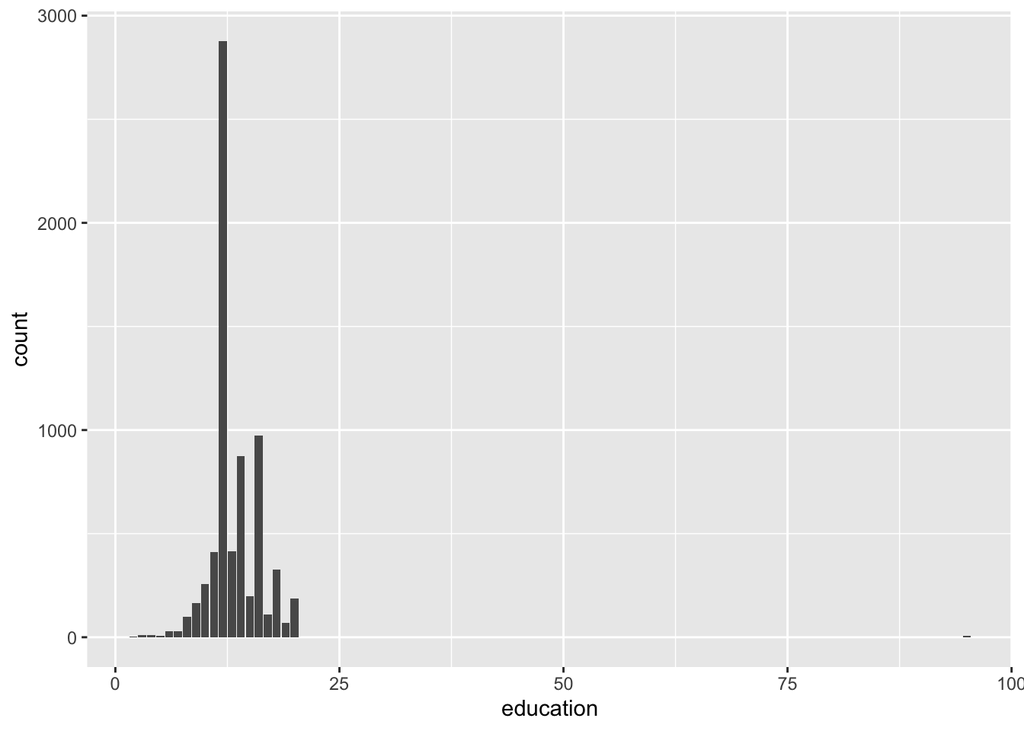

```r
ggplot(
  data = educ_phys_2014,
  aes(x = education)
) + geom_bar()
```

This plot reveals the spurious value, 95, meaning some ungraded education. We’ll exclude these from the analysis. Clearly, there are few of these values in the data.

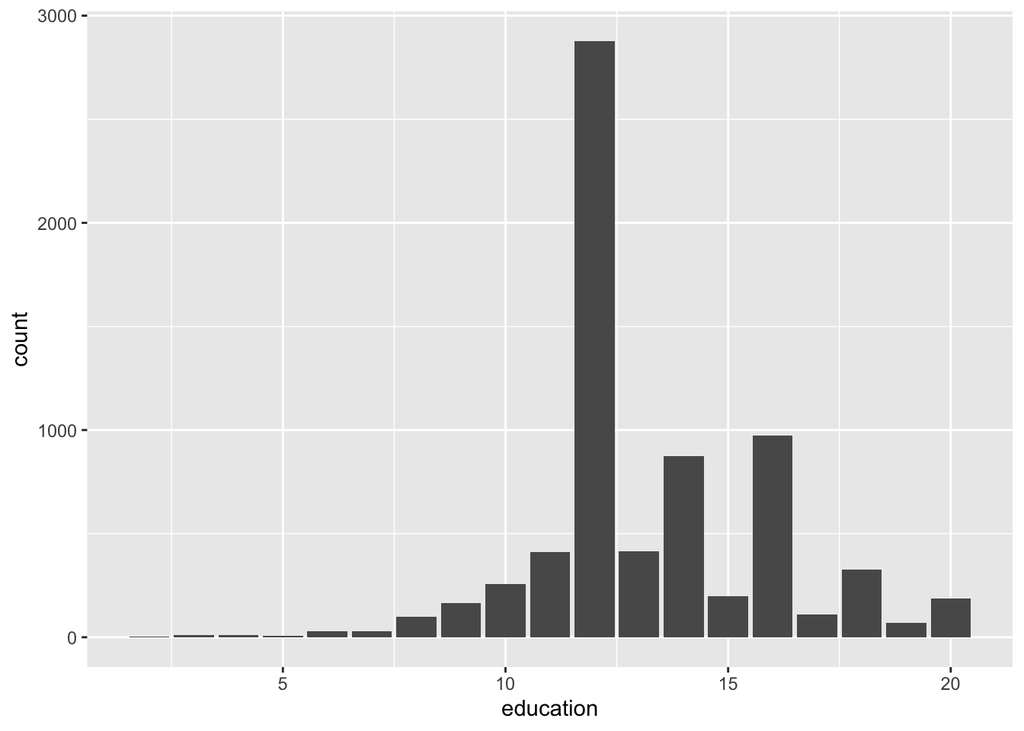

```r
ggplot(
  data = filter(educ_phys_2014, education < 95),
  aes(x = education)
) + geom_bar()
```

There are bumps in the distribution at 12 and 16 years as expected, and also 14 years, perhaps for associate degrees, and 18 years for an MBA or other 2-year master’s degree.

In how many cases is educational data non-missing?

```r
sum(!is.na(educ_phys_2014$education))
```

```
## [1] 7065
```

There are over 12,000 cases in all, so education is missing in many cases. However, 7000 is still a large number to study. Note that when you filter education data by `education < 95`, it also removes records with NA values.

There do not appear to be any additional anomalies in the education data that could represent erroneous values.

## Study of gender

Let’s plot sex to examine the distribution.

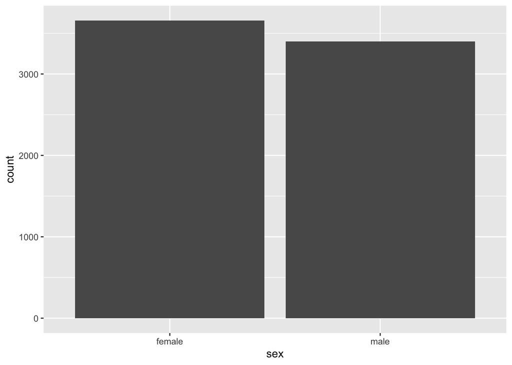

```r
ggplot(
  data = filter(educ_phys_2014, education < 95),
  aes(x = sex)
) + geom_bar()
```

The numbers of males and females are comparable.

```r
sum(is.na(educ_phys_2014$sex))
```

```
## [1] 0
```

There are no missing values.

## Study of race

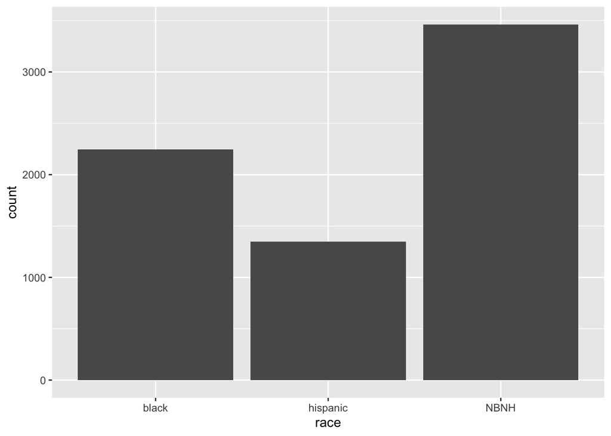

```r
ggplot(
  data = filter(educ_phys_2014, education < 95),
  aes(x = race)
) + geom_bar()
```

This shows that in each racial group we have over 1200 respondents. This is a high enough sample size for meaningful analysis.

```r
sum(is.na(filter(
  educ_phys_2014, education < 95)$race))
```

```
## [1] 0
```

No missing values.

## Explore the effects of sex on years of education

We’ll use a series of plots to get insight into this relationship. Sex is a categorical variable and years of education an integer that can take on many values, so we’ll first try a boxplot.

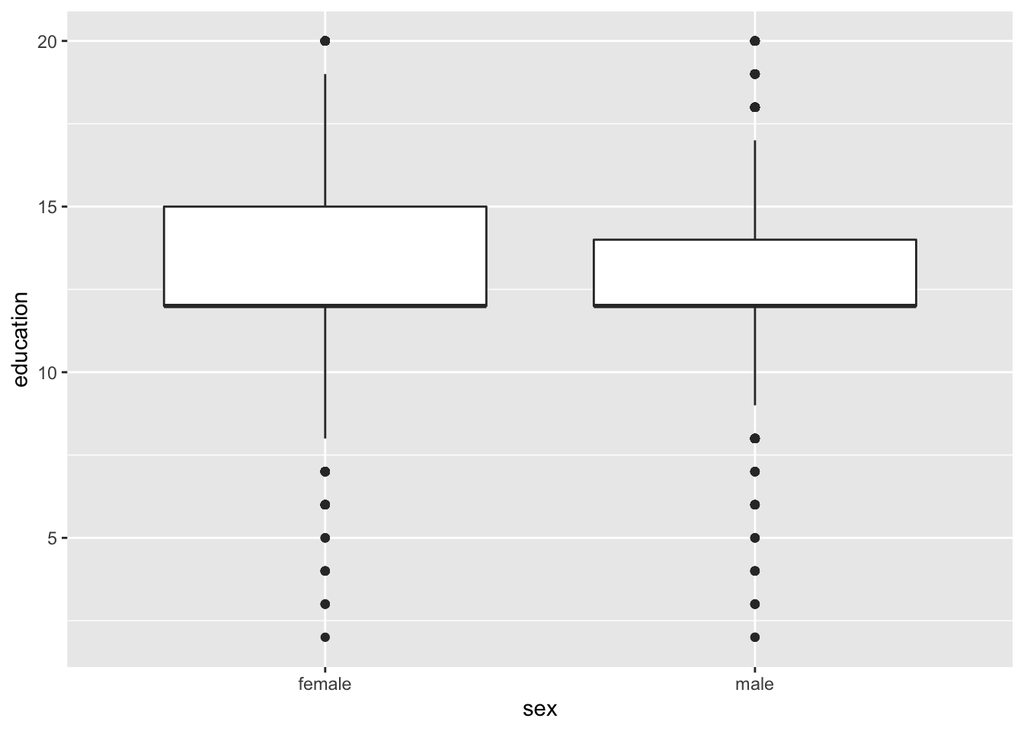

```r
ggplot(
  data = filter(educ_phys_2014, education < 95),
  aes(x = sex, y = education)
) + geom_boxplot()
```

The discrete nature of this integer education variable leads to irregularities in the boxplots. For example, it appears that the medians in both genders is at 12, which is also the 1st quartile. It does appear that the third quartile for females is higher than that for males.

For an analysis that provides more granularity, we plot bar plots faceted by gender.

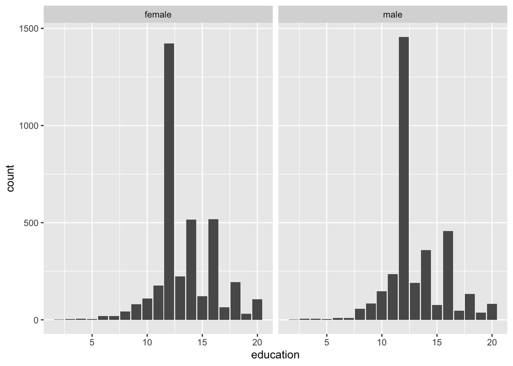

```r
ggplot(
  data = filter(educ_phys_2014, education < 95),
  aes(x = education)
) + geom_bar() + facet_wrap(~sex)
```

This histogram suggests that more females than males obtain college degrees and associate degrees (14 years of education). The numbers of high school graduates appear nearly the same for males and females.

## Education and race

Let’s use a faceted plot, as we did with sex.

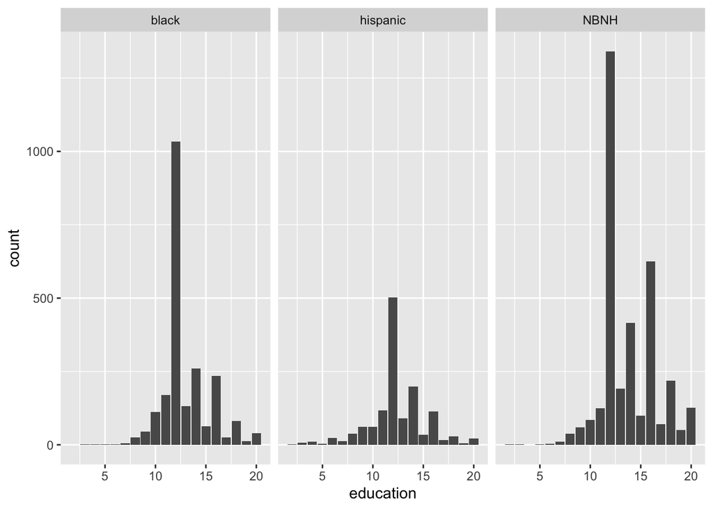

```r
ggplot(
  data = filter(educ_phys_2014, education < 95),
  aes(x = education)
) + geom_bar() + facet_wrap(~race)
```

These are difficult to analyze comparatively because of the differences in raw numbers of respondents in each racial group. We’re more interested in the proportions of respondents at each educational level. Googling for how to do this reveals the correct adjustment to the aesthetics.

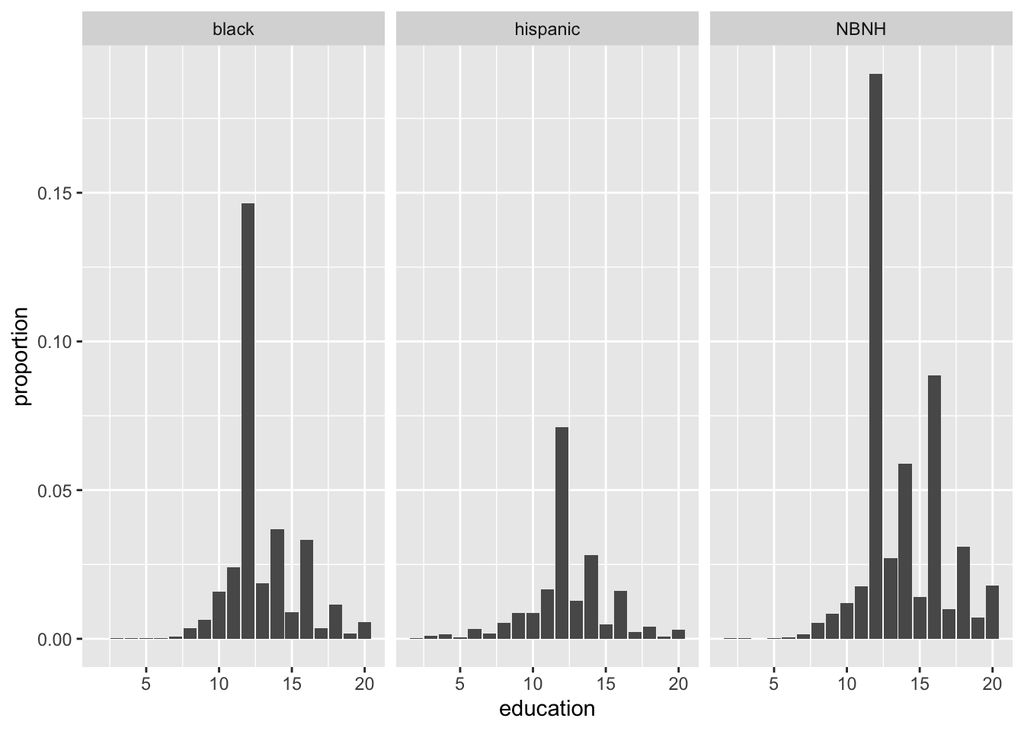

```r
ggplot(
  data = filter(educ_phys_2014, education < 95),
  aes(x = education)
) + geom_bar(aes(y = ..count../sum(..count..))) + facet_wrap(~race) + ylab("proportion")
```

There is certainly racial disparity in years of education at all levels from high school and beyond, With highest proportions for NBNH, then blacks and then Hispanics.

## Combined effects of gender and race on years of education

We have seen that both gender and race have some effect on the number of years of education. To deepen our understanding we would like to know if the effect of gender on years of education is the same for each race. It is challenging to make such a comparison in plots such as these. Multiple plots on different subsets of data may be necessary. In your own work, it may take several attempts to find the most informative plot or plots.

Below, we study the relationship between years of education and gender, separately for each racial group.

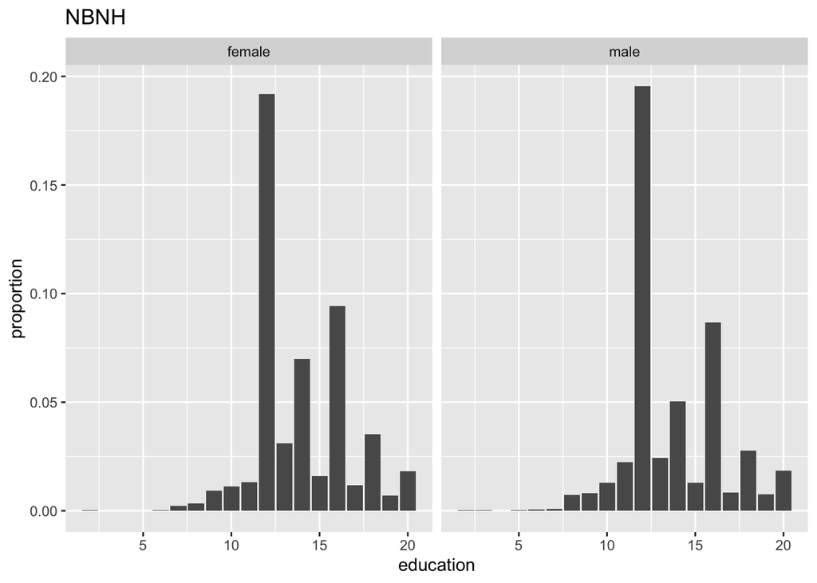

```r
ggplot(
  data = filter(educ_phys_2014,
                education < 95,
                race == "NBNH"),
  aes(x = education)
) + geom_bar(aes(y = ..count../sum(..count..))) + facet_wrap(~sex) + ylab("proportion") +
  ggtitle("NBNH")
```

There appear to be a slightly higher proportion of females at years above a high school diploma.

To set the focus on the education level at which we see some potential disparity, we further subset to education level above 12 years. Redo the above plot for this group.

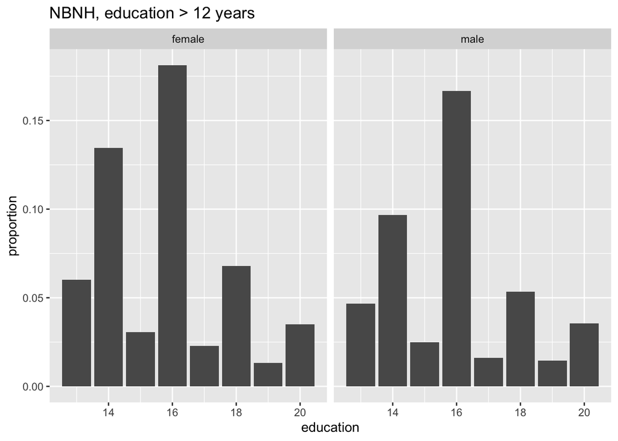

```r
ggplot(
  data = filter(educ_phys_2014,
                education < 95,
                education > 12,
                race == "NBNH"),
  aes(x = education)
) + geom_bar(aes(y = ..count../sum(..count..))) + facet_wrap(~sex) + ylab("proportion") +
  ggtitle("NBNH, education > 12 years")
```

There is a slightly higher proportion of females getting college and associates degrees.

Here is the plot for Blacks.

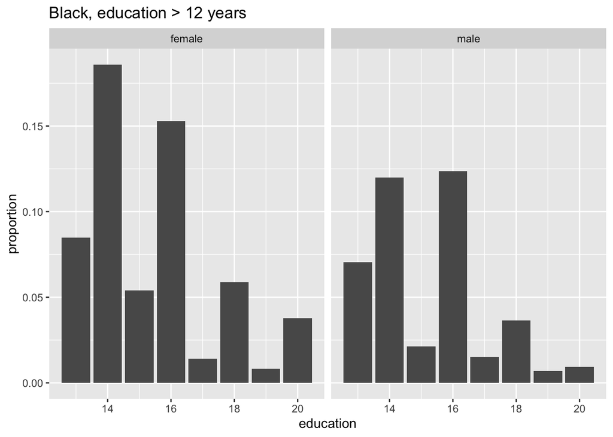

```r
ggplot(
  data = filter(educ_phys_2014,
                education < 95,
                education > 12,
                race == "black"),
  aes(x = education)
) + geom_bar(aes(y = ..count../sum(..count..))) + facet_wrap(~sex) + ylab("proportion") +
  ggtitle("Black, education > 12 years")
```

There is a similar gender disparity here, which may be slightly greater than for NBNH persons at the associates level and the post-graduate level.

Now plot the data for Hispanics.

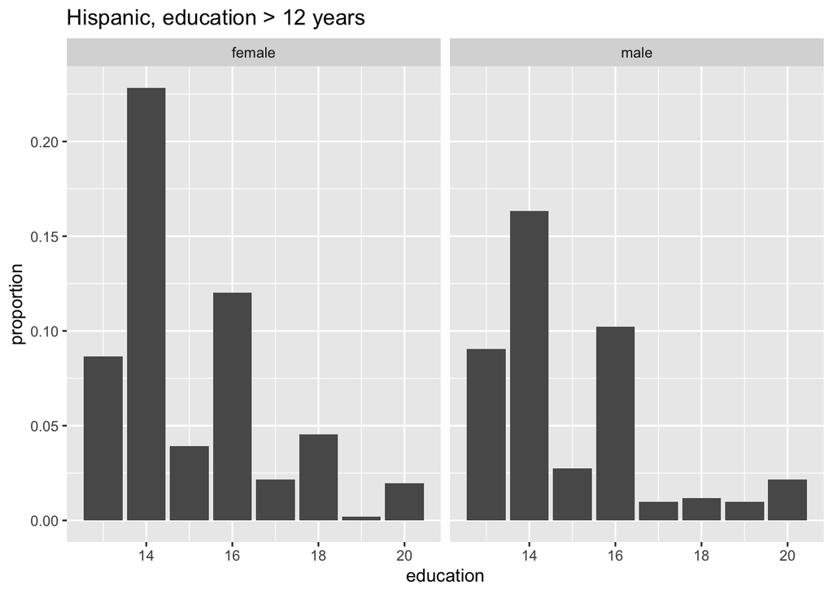

```r
ggplot(
  data = filter(educ_phys_2014,
                education < 95,
                education > 12,
                race == "hispanic"),
  aes(x = education)
) + geom_bar(aes(y = ..count../sum(..count..))) + facet_wrap(~sex) + ylab("proportion") +
  ggtitle("Hispanic, education > 12 years")
```

We have similar features here; perhaps less pronounced than in Black persons.

## Grouped analysis of summary statistics

Exploratory data analysis involves inspection of numeric measures as well as visualization. Analysis of statistical significance of some of the disparities illustrated above requires statistical tests you will learn later. However, we can compute some summary statistics of years of education for groups of individuals. As the summary statistic we use the mean.

### Mean years of education by gender

These are the means without consideration of race.

```r
filter(educ_phys_2014, education < 95) %>%
  group_by(sex) %>%
  summarise(mean_educ_years = mean(education, na.rm = T))
```

```
## # A tibble: 2 x 2
##   sex    mean_educ_years
##   <chr>            <dbl>
## 1 female            13.4
## 2 male              13.1
```

There is a slight increase here.

### Mean years of education by race

```r
filter(educ_phys_2014, education < 95) %>%
  group_by(race) %>%
  summarise(mean_educ_years = mean(education, na.rm = T))
```

```
## # A tibble: 3 x 2
##   race     mean_educ_years
##   <chr>              <dbl>
## 1 black               12.9
## 2 hispanic            12.4
## 3 NBNH                13.8
```

These differences are fairly large.

### Mean years of education by race and gender

Here we consider both race and sex in the grouped summary.

```r
filter(educ_phys_2014, education < 95) %>%
  group_by(race, sex) %>%
  summarise(mean_educ_years = mean(education, na.rm = T))
```

```
## # A tibble: 6 x 3
## # Groups:   race [3]
##   race     sex    mean_educ_years
##   <chr>    <chr>            <dbl>
## 1 black    female            13.2
## 2 black    male              12.7
## 3 hispanic female            12.5
## 4 hispanic male              12.3
## 5 NBNH     female            13.9
## 6 NBNH     male              13.7
```

The gender difference is positive for all races, and greatest for blacks.

### Proportion with more than 12 years education by race and gender

First consider race alone. This is data that reflects the last group of plots.

```r
filter(educ_phys_2014, education < 95) %>%
  group_by(race) %>%
  summarise(prop_over_12 = mean(education > 12))
```

```
## # A tibble: 3 x 2
##   race     prop_over_12
##   <chr>           <dbl>
## 1 black           0.379
## 2 hispanic        0.377
## 3 NBNH            0.519
```

Now analyze race and sex together.

```r
filter(educ_phys_2014, education < 95) %>%
  group_by(race, sex) %>%
  summarise(prop_over_12 = mean(education > 12))
```

```
## # A tibble: 6 x 3
## # Groups:   race [3]
##   race     sex    prop_over_12
##   <chr>    <chr>         <dbl>
## 1 black    female        0.432
## 2 black    male          0.320
## 3 hispanic female        0.409
## 4 hispanic male          0.342
## 5 NBNH     female        0.550
## 6 NBNH     male          0.487
```

Among NBNH and Hispanics, about 6% more females than males have education over 12 years. For blacks the difference in percentage is 11%.

## Hypotheses for further analysis

Based on the plots and the grouped summary analyses we state the following hypotheses.

1. The mean years of education is greater for females than males;
2. The mean years of education shows racial disparity, with NBNH persons having the highest number, followed by Blacks, followed by Hispanics;
3. The proportion of persons having education beyond 12 years shows a high degree of racial disparity, with much greater proportion of NBNH persons having such education and Blacks and Hispanics having comparable proportions at a much lower level.
4. The proportion of persons having education beyond 12 years shows gender disparity that depends on race. The difference in proportion of females compared to males appears to be significantly greater in Blacks than NBNH and Hispanic races.

Testing the statistical significance of these hypotheses requires statistical analyses to be learned later.